# Economic impact of presidents and war: Did FDR or WW2 End the Great Depression?

Spencer Graves and Jouni Helske

2016-09-19

# Abstract

Economists claim that World War II (WW2) not Franklin Roosevelt (FDR) ended the Great Depression. U.S. average annual income (Gross Domestic Product, GDP, per capita adjusted for inflation) grew by 10.6 percent per year during WW2 (1939-1945) and only 6.2 percent per year under FDR before the war (1933-1939). If WW2 not FDR ended the Great Depression, we would expect to see (a) similar growth spurts during other wars, and (b) sufficient variability between the economic growth during other presidencies to make FDR’s performance consistent with that of other presidents. We analyze GDP data 1790-2015 with unemployment 1800-2015. Our findings have implications for both economics and statistical modeling: (1) We find a president but not a war effect on GDP. (2) We find a war but not a president effect on unemployment. (3) The correlation between the state-space increments of the levels of GDP and unemployment was (-1) consistent with Okun’s Law. (4) Nonlinear optimization is still difficult. Constrained optimizers seemed to give the best results for models where we saw estimation difficulties; in those cases, we preferred parameterizations in terms of standard deviations and correlations.

**Key Words**: Kalman filtering and smoothing, KFAS, R (programming language), econometrics, gross domestic product (GDP), unemployment, Okun’s Law

# Introduction

We begin this article with a brief review of typical perspectives of US economic performance during the Great Depression and World War II. We then consider a few plots of available data. That is followed by a summary of models we fit. This is an interim report on research discussed in a vignette on “Modeling Gross Domestic Product and unemployment with the KFAS package for R” included with the [Ecdat](https://rweb.crmda.ku.edu/cran/web/packages/Ecdat/Ecdat.pdf) package for R, with the most current version available from [R-Forge](https://r-forge.r-project.org/R/?group_id=1439).

In brief, we do not find growth spurts associated with wars other than WW II, but we do find that major wars have driven down unemployment. Moreover, the economic growth of the US economy under FDR dramatiacally exceeded that of other presidents. Beyond that we found a correlation of (-1) between state-space increments of the levels of GDP and unemployment, consistent with [Okun’s Law](https://en.wikipedia.org/wiki/Okun%27s_law).

For this we use the [KFAS (Kalman filtering and smoothing)](https://rweb.crmda.ku.edu/cran/web/packages/KFAS/KFAS.pdf) package for R. This work exposed problems using the standard [optim](https://stat.ethz.ch/R-manual/R-devel/library/stats/html/ts.html) nonlinear optimizer for some of our models. We initially followed the example of the [nlme](https://rweb.crmda.ku.edu/cran/web/packages/nlme/nlme.pdf) package in parameterizing variance parameters on a log scale. When we perceived problems with that, we tried constrained optimization, parameterizing the problem in terms of standard deviations and correlations, as suggested by [Bates, Mächler, Bolker, and Walke (2014)](https://cran.rstudio.com/web/packages/lme4/vignettes/lmer.pdf,%20accessed%202016-03-01). In one such case, a standard optim(…, method=‘L-BFGS-B’) call stopped with a negative standard deviation. That problem was overcome by switching to a different nonlinear optimizer, as suggested by [Bates, Mächler, Bolker, et al. (2014)](https://cran.rstudio.com/web/packages/lme4/vignettes/lmer.pdf,%20accessed%202016-03-01). However, our limited tests suggest that the other optimizers may be more fragile than optim(…, method=‘L-BFGS-B’), and the best strategy may be to parameterize everything on constrained square root and correlation scales, and try at least two different optimizers.

For average annual income (GDP per capita, adjusted for inflation) we use data from [Johnston and Williamson (2016)](http://www.measuringworth.org/usgdp/,%20accessed%202016-03-01). For unemployment we used multiple sources, documented with the [USGDPpresidents](https://rweb.crmda.ku.edu/cran/web/packages/Ecdat/USGDPpresidents.pdf) data.frame in the [Ecdat](https://rweb.crmda.ku.edu/cran/web/packages/Ecdat/Ecdat.pdf) package for R.

# US Economic Performance during the Great Depression and World War II

The Legacy of the [Great Depression](https://en.wikipedia.org/wiki/Great_Depression) and the [New Deal](https://en.wikipedia.org/wiki/New_Deal) still carry profound implications for the current economic policies of the world’s most economically advanced countries. [Horowitz (2011)](http://www.cato.org/publications/briefing-paper/herbert-hoover-father-new-deal,%20accessed%202016-02-27) recently claimed that Hoover had more aggressive deficit spending and public works programs than [Franklin Roosevelt (FDR)](https://en.wikipedia.org/wiki/Franklin_D._Roosevelt), and far from contributing to the recovery these programs actually made the economy worse. He concluded that “The persistence of the Hoover myth continues to justify the counterproductive policies of the Obama administration and thereby prevents markets from generating the economic recovery of which they are fully capable.” However, Horowitz’s report discusses no model fits, includes no tables, and plots only “real federal spending” from 1929 to 1934.

The dominant view of the evolution of the US economy between 1933 and 1945 is that World War [World War II (WW II)](https://en.wikipedia.org/wiki/Great_Depression#World_War_II_and_recovery), not FDR, ended the [Great Depression](https://en.wikipedia.org/wiki/Great_Depression). This perspective is supported by our review of the available unemployment data but superficially contradicted by our naive analyses of average annual income in the US ([real US Gross Domestic Product (GDP) per capita](https://en.wikipedia.org/wiki/Real_gross_domestic_product), 1790-2015, from [MeasuringWorth](http://measuringworth.com/)): First, other wars have not been accompanied by such obvious growth spurts. Second, FDR’s economic performance even without World War II seems unmatched by any other U.S. president.

McChesney (2014) said, “In earlier eras it had been assumed that there was an economic ‘guns and butter’ tradeoff, and that military spending had to occur at the expense of other sectors of the economy. However, one of the lessons of the economic expansion in Nazi Germany, followed by the experience of the United States itself in arming for the Second World War, was that big increases in military spending could act as huge stimulants to the economy.”

Other research identified alternatives that would reportedly produce more jobs than military spending: Tax cuts for household consumption and increased spending on clean energy, health care and education would produce 27, 47, 69 and 151 percent more jobs, respectively, than military spending, according to [Pollin and Garrett-Peltier (2009)](http://www.peri.umass.edu/236/hash/0b0ce6af7ff999b11745825d80aca0b8/publication/489/,%20accessed%202016-03-08).

However, these claims are not universally accepted among economists. [Barro (2013)](https://www.imf.org/external/np/seminars/eng/2013/fiscal/pdf/barro.pdf,%20accessed%202016-09-09) cited a dozen different empirical studies that estimated the multiplier effect of military spending. These studies provide estimates that range from less than zero to roughly 1.4 with a median of 0.6 for those with numbers in Barro’s table. Barro explained that if this multiplier is greater than 1, it means that cuts in defense spending also reduce the private portions of GDP. If it’s positive but less than 1, it means that the private sector increases but by less than the fall in defense. If it’s negative it means that private economic activity rises by more than the fall in defense spending. The work of [Pollin and Garrett-Peltier (2009)](http://www.peri.umass.edu/236/hash/0b0ce6af7ff999b11745825d80aca0b8/publication/489/,%20accessed%202016-03-08) suggests that the multiplier effect of a cut in military spending depends on what is done with the defense savings.

Beyond this, the work of [Milton Friedman](https://en.wikipedia.org/wiki/Milton_Friedman) and others suggests that models like these should also consider [inflation](https://en.wikipedia.org/wiki/Inflation) and [unemployment](https://en.wikipedia.org/wiki/Unemployment); we consider unemployment but not inflation.

Whatever the specific cause, the growth of the U.S. economy under [FDR](https://en.wikipedia.org/wiki/Franklin_D._Roosevelt) before the war signficantly exceeds that of any other president (not counting the negative record of [Herbert Hoover](https://en.wikipedia.org/wiki/Herbert_Hoover)).

This document is a summary of research not yet completed but described in detail in a vignette on “Modeling Gross Domestic Product and unemployment with the KFAS package for R” included with the [Ecdat](https://rweb.crmda.ku.edu/cran/web/packages/Ecdat/Ecdat.pdf) package, with the most current version available from [R-Forge](https://r-forge.r-project.org/R/?group_id=1439).

We used GDP data from [Johnston and Williamson (2016)](http://www.measuringworth.org/usgdp/,%20accessed%202016-03-01), included as the [USGDPpresidents](http://rpackages.ianhowson.com/cran/Ecdat/man/USGDPpresidents.html) data set in the Ecdat package (currently only available in the [R-Forge](https://r-forge.r-project.org/R/?group_id=1439) version of the package). This [data.frame](https://stat.ethz.ch/R-manual/R-devel/library/base/html/data.frame.html) also includes unemployment data from multiple sources as documented int its help page.

We have conclusions for both economics and statistical methods:

```
(E1) The models we fit failed to find a signficant effect of war on real GDP per capita but did find that the performance of the U.S. economy under the Hoover and FDR administrations was dramatically different from that for any other presidency.

(E2) We reach the opposite conclusion from modeling unemployment:  We find a war but not an administration effect.

(E3) We present a state-space version of Okun's law, estimating a correlation of (-1) in the random increments for the state space components representing the levels of unemployment and GDP.

(E4) These conclusions must be considered tentative, because these models do not consider other variables like inflation that might impact economic growth and unemployment, and our work is still in progress.

(S1) The companion vignette included with the Ecdat package for R includes several examples of convergence problems using the standard optim numerical optimizer. Most of these came from using unconstrained optimization over log(variance) parameters, following the pattern in the nlme package for R.  When we lacked confidence in the unconstrained optimization, we reparameterized in terms of standard deviations and correlations;  Bates et al. (2014) say that a quadratic will generally approximate the log(likelihood) surface better in that parameterization.  Sadly, we encountered problems also with constrained optimization.  In one case optim(..., method = 'L-BFGS-B') failed while testing parameter values out of bounds.  We fixed this by using an alternative optimizer.  Unfortunately, we have so far not found a single constrained optimizer that seemed to work well for us in all cases.  We're inclined to start with optim(..., method = 'L-BFGS-B') and switch to BOBYQA in the minqa package or Nelder-Mead, BOBYQA, or COBYLA in the nloptr package if we encounter a problem or want to check convergence.  However, this is not based on exhaustive testing.

(S2) More generally, KFAS provides a powerful set of tools for modeling extensions to the present analysis, e.g., mixing annual and quarterly data or adding other variables such as inflation to our models of GDP per capita with unemployment.
```

# Initial Plots

We start by plotting the [MeasuringWorth](http://measuringworth.com/) estimates of average annual income in the US (adjusted for inflation) from 1790 to 2015:

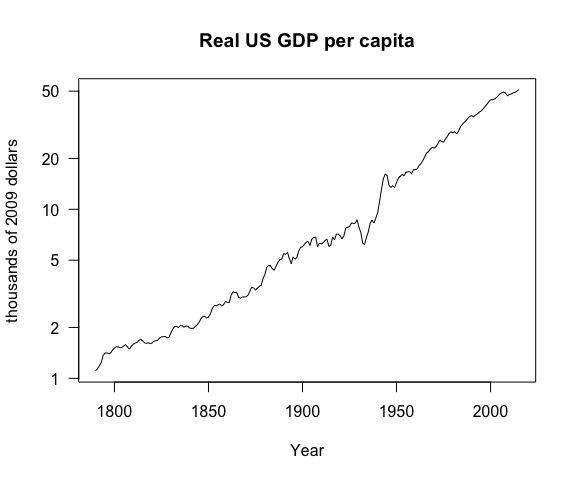

real US GDP per capita (thousands of 2009 $)

This plot suggests relatively steady growth from 1790 to 2015 with the exception of a dramatic rise roughly two thirds of the way through the series preceded and followed by declines.

Many readers will likely suspect that this exceptional period corresponds to the [Great Depression](https://en.wikipedia.org/wiki/Great_Depression), [World War II (WW II)](https://en.wikipedia.org/wiki/Great_Depression#World_War_II_and_recovery), and the administrations of [Herbert Hoover](https://en.wikipedia.org/wiki/Herbert_Hoover) and [Franklin Roosevelt (FDR)](https://en.wikipedia.org/wiki/Franklin_D._Roosevelt).

We now ask the reader: Can you see in this plot any macroeconomic impact of the First World War, the Civil War or any other war in US history?

It may be there, but it does not jump at us like the Hoover-FDR period does. To help us evaluate this, we created a variable for war, defined as a violent conflict that averaged over 10 battle deaths per million population per year. To operationalize that definition, we created variables for approximate battle deaths per year (battleDeaths) and approximate battle deaths per million population per year (battleDeathsPMP). These varables are included in [USGDPpresidents](http://rpackages.ianhowson.com/cran/Ecdat/man/USGDPpresidents.html). We plot battleDeathsPMP here with labels for the wars and for the Hoover-FDR period:

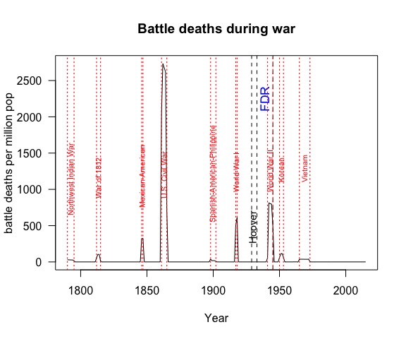

Battle deaths per million population

The 2001-2014 War in Afghanistan and the 2003-2011 [Iraq war](https://en.wikipedia.org/wiki/Iraq_War) do not appear here, because together they averaged fewer than 3 battle deaths per year per million population. One might argue that they were more like the [Super Bowl](https://en.wikipedia.org/wiki/Super_Bowl) than World War II in terms of their impact on the U.S. economy.

We also model unemployement, with numbers taken from four different sources as documented in [help(USGDPpresidents)](http://rpackages.ianhowson.com/cran/Ecdat/man/USGDPpresidents.html):

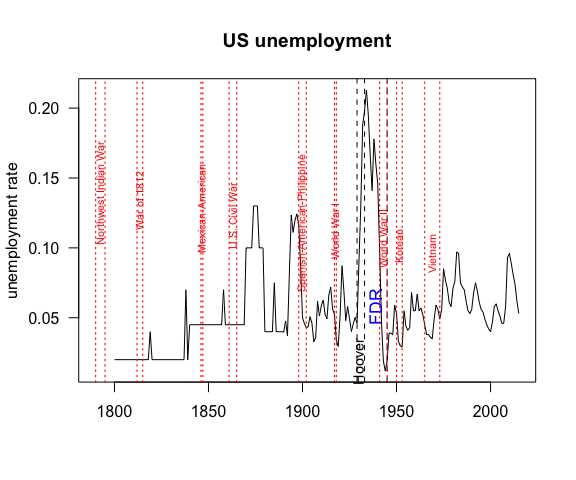

Presidents, wars & unemployment

The unemployment numbers prior to 1890 clearly do not track the state of the economy as well as the more recent data. More to the point of the present discussion, the unemployment climbed almost vertically during the Hoover years and fell dramatically during the administration of FDR. Closer study suggests that unemployment fell rapidly during all wars for which we have reasonable data except for Vietnam. It’s less clear from this image if unemployment fell more rapidly during FDR but prior to World War II than it has under other presidencies. We need models for that – and, as noted elsewhere in this report, the models did not support an exceptional FDR effect on unemployment.

# Choice of scales

We model income data on a log scale, consistent with the above plot of realGDPperCapita.

To look at the difference, we redo here the above plot of unemployment:

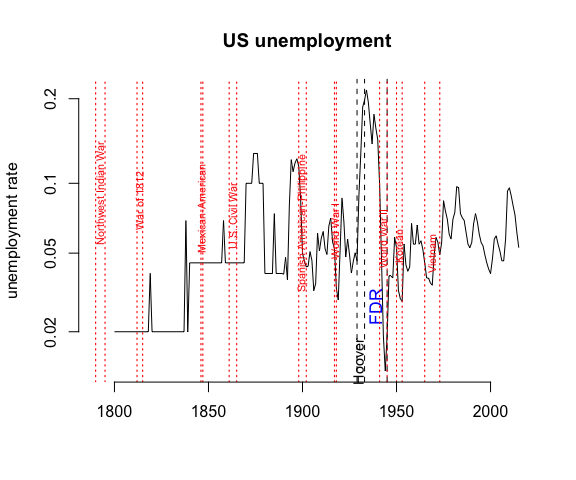

Presidents, wars & probit(unemployment)

The dramatic nature of the impact of World War II is more visible in this plot than in the above plot of the untransformed data. We think most serious observers would agree that it’s more difficult to reduce unemployment from 2 percent to 1.2 percent (the lowest level recorded) than from 10 percent to 9 percent, for example. Use of this transformed scale provides an automatic acknowledgement of that increased difficulty.  
[USGDPpresidents](https://rweb.crmda.ku.edu/cran/web/packages/Ecdat/USGDPpresidents.pdf) includes a variable, “unempSource” indicating the source of the numbers used here. This is an ordered factor, and we can order a count of observations by its levels:

```
##
## Lebergott     Romer      Coen       BLS
##        90        41         9        76
```

The help page for USGDPpresidents says that Lebergott is the source for the data until 1890, and Romer’s data are used through 1930. The current standard source, [the US Bureau of Labor Statistics (BLS)](https://en.wikipedia.org/wiki/Bureau_of_Labor_Statistics), has data starting in 1940.

Economists also claim that low unemployment tends increase [inflation](https://en.wikipedia.org/wiki/Inflation), a relationship called the [Phillips curve](https://en.wikipedia.org/wiki/Phillips_curve). [Another reason for using a transformation like probits, i.e., qnorm(unemployment), is that it might tend to linearize the “curve” that observed in unemployment in the [United Kingdom](https://en.wikipedia.org/wiki/United_Kingdom) from 1913 to 1948.)

Inflation is widely calculated from changes in a price index, usually the consumer price index. The CPI is included in the GDP data.frame, but we’ll skip that for the present discussion.

We next briefly outline the general Kalman framework. This is followed by an overview of the alternative models fit so far in the companion vignette included in the [Ecdat](https://rweb.crmda.ku.edu/cran/web/packages/Ecdat/Ecdat.pdf) package for R. This article ends with a brief discussion of future work in this area.

# Kalman Filtering and Smoothing

The theory behind these models can be described in terms of a 3-step Bayesian updating cycle to add new observations to a probability distribution summarizing the available knowledge about the state of the system under study (Graves, 2007):

1. Receive and store new data.
2. Create a prior distribution for the new data by modifying the posterior computed after the last observation to allow for possible changes in state in the time between the last and current observations.
3. Combine the new data with the prior to produce a posterior distribution of the state.

Three different names are commonly used for this class of models. The oldest name is ‘Kalman filtering (and smooting)’, recognizing the path-breaking contributions of [Rudolf E. Kálmán](https://en.wikipedia.org/wiki/Rudolf_E._K%C3%A1lm%C3%A1n). A more descriptive term for this class of models is “state space”, recognizing the central role of the indirectly observed “state” in these models; this term is used by Durbin and Koopman (2012a). West and Harrison (1997) call these “Dynamic (linear) models.”

In the present discussion, the system under study is the US economy at various times, which we will summarize in a vector of one or more numbers that represent the state or condition of the economy at each point in time. (The term “state” in “state space” refers to this type of representation.) The data will be annual observations on real US GDP per capita (realGDPperCapita) and / or unemployment, as previously discussed.

Our primary reference for Kalman filtering is Durbin and Koopman (2012b). In brief, we assume that time series observations $y_t$, $t$ = 1, 2, …, are linear functions of some latent state vector, $\alpha_t$, plus observation error:

$$y_t = Z_t \alpha_t + \epsilon_t$$

$$\alpha_{t+1} = T_t \alpha_t + R_t \eta_t.$$

where $\epsilon_t \tilde\ N(0, H_t)$, $\eta_t \tilde\ N(0, Q_t)$ and $\alpha_1 \tilde\ N(a_1, P_1)$, independent of each other. In this, $y_t$ is a $p$-vector (where $p$ may actually vary with $t$), $\alpha_t$ is $m$-dimensional, and $\eta_t$ has dimension $k$. (See Durbin and Koopman (2012a) for more detail on the theory behind this model or Helske (2016) for more on the KFAS implementation.)

The first of these two equations is called the “observtion equation”. The second is called the “state transition equation”. When a new observation arrives, we first degrade the posterior from the previous observation to obtain a prior for the new observation to model the loss of knowledge about the state by the addition of migration noise per the state transition equation. Then we apply Bayes’ theorem to get a new observation, as outlined with the 3-step cycle above. This is Kalman filtering. Kalman smoothing then runs time backward using similar math to produce posterior estimates of the state at each point in time given all the data, not just the previous data.

In the models considered here, $y_t$ is log(realGDPperCapita) or qnorm(unemployment) or both. The dimensionality of $\alpha_t$ will vary, but the first component(s) will always be the level. With a univariate response, $Z_t$ will be a row vector with 1 in the first position and 0 elsewhere. With a bivariate respose, $Z_t$ will have two rows, with the first two columns being an identity matrix and the rest being zero.

This will force $Q_t$, $T_t$, and $P_1$ to change between models. In addition, some models have diffuse initialization for the state vector. These are specified by a model component $P_{1,\infty}$; see Helske (2016) or [SSmodel](http://rpackages.ianhowson.com/cran/KFAS/man/logLik.SSModel.html).

And the different models require estimating different parameters. These pieces are summarized in the following table:

|  | Response | Model | state vector compo- nents | time-varying compo-nents | P1 | P1inf | parameters to estimate |
| --- | --- | --- | --- | --- | --- | --- | --- |
| 1 | GDP/cap | EWMA1: Standard Bayesian EWMA | 1:level |  | 0 | 1 | 2:Q, H |
| 2 | GDP/cap | EWMA2: double EWMA | 2:level, slope |  | 0 | diag(2) | 3:Q.lvl, Q.slope, H |
| 3 | GDP/cap | EWMA2pres1: EWMA2 allowing slope to change only between presidents | 2:level, slope | Q | 0 | diag(2) | 3:Q.lvl, Q.slope, H |
| 4 | GDP/cap | EWMA2pres2: EWMA2 estimating mean slope and no continuity between presidents | 3:level, slope, a1.slope | T, Q | diag(c(0, NA, 0)) | diag(c(1, 0, 0)) | 4:a1.slope, Q.lvl, Q.slope, H |
| 5 | GDP/cap | EWMA2pres3: EWMA2 with an adjustment for each president | 3:level, slope, pres3 | T, Q | diag(c(0, 0, NA) | diag(c(1, 1, 0)) | 4:Q.lvl, Q.slope, Q.pres3, H |
| 6 | GDP/cap | EWMA2war0: EWMA2 with fixed effect of war | 4:level, slope, war, deaths | T | 0 | diag(4) | 3:Q.lvl, Q.slope, H |
| 7 | GDP/cap | EWMA2war1: EWMA2 with random effect of war | 4:level, slope, war, deaths | T, Q | diag(c(0, 0, Q.war)) | diag(c(1, 1, 0, 0)) | 6:Q.lvl, Q.slope, Q.war, Q.deaths, Q.warDeaths, H |
| 8 | GDP/cap | EWMA2war2: EWMA2 with variance effect for war | 2:level, slope | Q | 0 | diag(2) | 5:Q.lvl, Q.slope, Q.war, Q.deaths, H |
| 9 | unemp | uEWMA1: Standard Bayesian EWMA | 1:level |  | 0 | 1 | 2:Q, H |
| 10 | unemp | uEWMA1a: EWMA with higher error variance for older data | 1:level | H | 0 | 1 | 5:Q, H1..4 |
| 11 | unemp | uEWMA1pres3: EWMA with a slope adjustment for each president | 2:level, pres3 | T, Q, H | diag(c(0, NA)) | diag(c(1, 0)) | 6:Q.lvl, Q.pres3, H1..4 |
| 12 | unemp | uEWMA1war0: EWMA with fixed slope adjustments for war | 3:level, war, deaths | T, H | 0 | diag(3) | 5:Q.lvl, H1..4 |
| 13 | unemp | uEWMA1war1: EWMA with radom slope adjustments for war | 3:level, war, deaths | T, Q, H | diag(c(0, Q.war)) | diag(3) | 8:Q.lvl, Q.war, Q.deaths, Q.warDeaths, H1..4 |
| 14 | GDP/cap & unemp | Okun: [Okun’s law](https://en.wikipedia.org/wiki/Okun's_law) | 3:GDP.lvl, unemp.lvl, GDP.slope | H | 0 | diag(3) | 10:Q.pl, Q.ul, Q.ps, Q.pl.ul, Q.ul.ps, Hp, Hu1..4 |

We will limit the discussion in this interim report to these models. We expect, however, that fitting other similar models would likely support a deeper understanding of the macroeconomic impact of presidents and wars.

Details of the exact structure of the matrices in each model are available in companion vignette included in the [Ecdat](https://rweb.crmda.ku.edu/cran/web/packages/Ecdat/Ecdat.pdf) package for R.

Let’s look for a variance effect of war, similar to EWMA2war2:

[output not shown]

Unfortunately, Wilk’s theorem does not apply when the null hypothesis is on a boundary, as with a variance parameter at 0. In that case, the likelihood ratio is still most powerful, but twice the log(likelihood ratio) may not be approximately chi-square. Pinheiro and Bates (2000) recommend simulation to estimate p-values. They provide simulations that suggest that in cases like these, the p-values per Wilk’s theorem tend to be larger than the actual (simulated) p-values by factors ranging from 1 to 3. If that’s accurate for these cases, then a nominal p-value of 0.05 means that it likely is significant at that level, which a nominal p-value of 0.10 says that it might be significant at the 0.05 level but not at the 0.02 level, for example.